# Machine Learning: AllLife Bank Personal Loan Campaign

### Cost Complexity Pruning

```python
clf = DecisionTreeClassifier(random_state=1)
path = clf.cost_complexity_pruning_path(X_train, y_train)
ccp_alphas, impurities = path.ccp_alphas, path.impurities
```

```python
pd.DataFrame(path)
```

|  | ccp_alphas | impurities |
| --- | --- | --- |
| 0 | 0.000000 | 0.000000 |
| 1 | 0.000215 | 0.001292 |
| 2 | 0.000317 | 0.001927 |
| 3 | 0.000412 | 0.003162 |
| 4 | 0.000444 | 0.004494 |
| 5 | 0.000500 | 0.004994 |
| 6 | 0.000500 | 0.005494 |
| 7 | 0.000500 | 0.006494 |
| 8 | 0.000571 | 0.007065 |
| 9 | 0.000611 | 0.007676 |
| 10 | 0.000625 | 0.008301 |
| 11 | 0.000762 | 0.009063 |
| 12 | 0.000878 | 0.012574 |
| 13 | 0.000889 | 0.013463 |
| 14 | 0.000960 | 0.014423 |
| 15 | 0.001000 | 0.015423 |
| 16 | 0.001071 | 0.016495 |
| 17 | 0.001091 | 0.017586 |
| 18 | 0.001192 | 0.018778 |
| 19 | 0.001729 | 0.020507 |
| 20 | 0.001971 | 0.024449 |
| 21 | 0.002238 | 0.026687 |
| 22 | 0.002429 | 0.029116 |
| 23 | 0.004594 | 0.033711 |
| 24 | 0.004610 | 0.038320 |
| 25 | 0.004751 | 0.043071 |
| 26 | 0.023224 | 0.089518 |
| 27 | 0.036018 | 0.125536 |
| 28 | 0.047493 | 0.173029 |

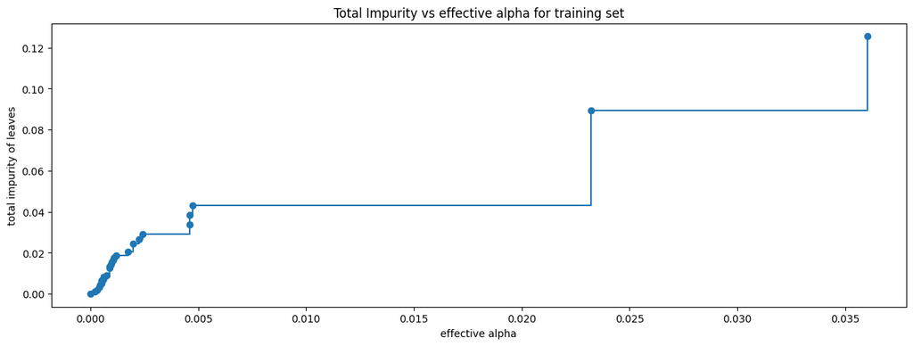

```python
fig, ax = plt.subplots(figsize=(15, 5))
ax.plot(ccp_alphas[:-1], impurities[:-1], marker="o", drawstyle="steps-post")
ax.set_xlabel("effective alpha")
ax.set_ylabel("total impurity of leaves")
ax.set_title("Total Impurity vs effective alpha for training set")
plt.show()
```

Next, we train a decision tree using the effective alphas. The last value in `ccp_alphas` is the alpha value that prunes the whole tree, leaving the tree, `clfs[-1]`, with one node.

```python
clfs = []
for ccp_alpha in ccp_alphas:
    clf = DecisionTreeClassifier(random_state=1, ccp_alpha=ccp_alpha)
    clf.fit(X_train, y_train)
    clfs.append(clf)
print(
    "Number of nodes in the last tree is: {} with ccp_alpha: {}".format(
        clfs[-1].tree_.node_count, ccp_alphas[-1]
    )
)
```

```
Number of nodes in the last tree is: 1 with ccp_alpha: 0.04749278966498974
```

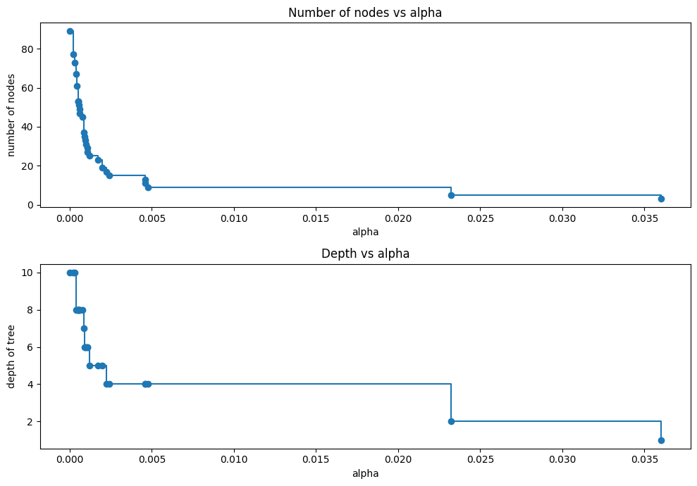

```python
clfs = clfs[:-1]
ccp_alphas = ccp_alphas[:-1]

node_counts = [clf.tree_.node_count for clf in clfs]
depth = [clf.tree_.max_depth for clf in clfs]
fig, ax = plt.subplots(2, 1, figsize=(10, 7))
ax[0].plot(ccp_alphas, node_counts, marker="o", drawstyle="steps-post")
ax[0].set_xlabel("alpha")
ax[0].set_ylabel("number of nodes")
ax[0].set_title("Number of nodes vs alpha")
ax[1].plot(ccp_alphas, depth, marker="o", drawstyle="steps-post")
ax[1].set_xlabel("alpha")
ax[1].set_ylabel("depth of tree")
ax[1].set_title("Depth vs alpha")
fig.tight_layout()
```

### Recall vs alpha for training and testing sets

```python
recall_train = []
for clf in clfs:
    pred_train = clf.predict(X_train)
    values_train = recall_score(y_train, pred_train)
    recall_train.append(values_train)
```

```python
recall_test = []
for clf in clfs:
    pred_test = clf.predict(X_test)
    values_test = recall_score(y_test, pred_test)
    recall_test.append(values_test)
```

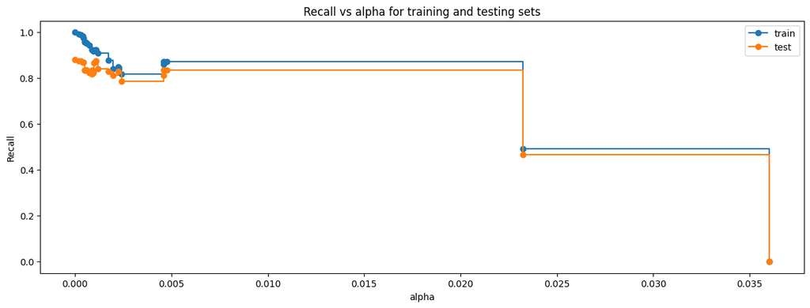

```python
fig, ax = plt.subplots(figsize=(15, 5))
ax.set_xlabel("alpha")
ax.set_ylabel("Recall")
ax.set_title("Recall vs alpha for training and testing sets")
ax.plot(ccp_alphas, recall_train, marker="o", label="train", drawstyle="steps-post")
ax.plot(ccp_alphas, recall_test, marker="o", label="test", drawstyle="steps-post")
ax.legend()
plt.show()
```

```python
# creating the model where we get highest train and test recall
# We can choose alpha = 0.0020
# Adding class_weight to balance the tree
best_model = DecisionTreeClassifier(
    ccp_alpha=0.002, class_weight={0: 0.15, 1: 0.85}, random_state=1)
best_model.fit(X_train, y_train)
```

```
DecisionTreeClassifier(ccp_alpha=0.002, class_weight={0: 0.15, 1: 0.85},
                       random_state=1)
```

### Checking model performance on training set

```python
decision_tree_postpruned_perf_train = model_performance_classification_sklearn(
    best_model, X_train, y_train
)
decision_tree_postpruned_perf_train
```

|  | Accuracy | Recall | Precision | F1 |
| --- | --- | --- | --- | --- |
| 0 | 0.979333 | 1.0 | 0.82235 | 0.902516 |

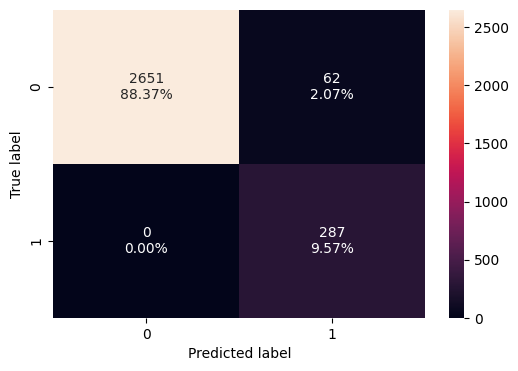

```python
confusion_matrix_sklearn(best_model, X_train, y_train)
```

After Post pruning with ccp_alpha, Train data has 100% recall

### Checking model performance on test set

```python
decision_tree_postpruned_perf_test = model_performance_classification_sklearn(
    best_model, X_test, y_test
)
decision_tree_postpruned_perf_test
```

|  | Accuracy | Recall | Precision | F1 |
| --- | --- | --- | --- | --- |
| 0 | 0.9655 | 0.932642 | 0.762712 | 0.839161 |

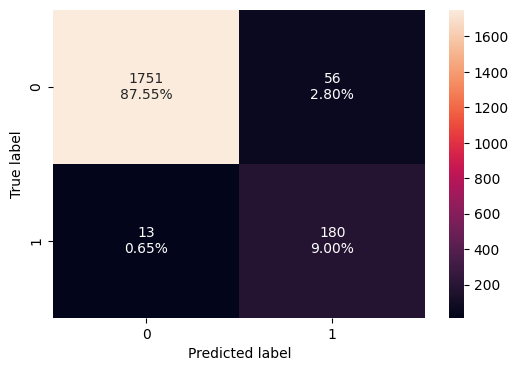

```python
confusion_matrix_sklearn(best_model, X_test, y_test)
```

After Post pruning with ccp_alpha and highest Recall value, recall is 93% on the test data.

### Visualizing the Decision Tree

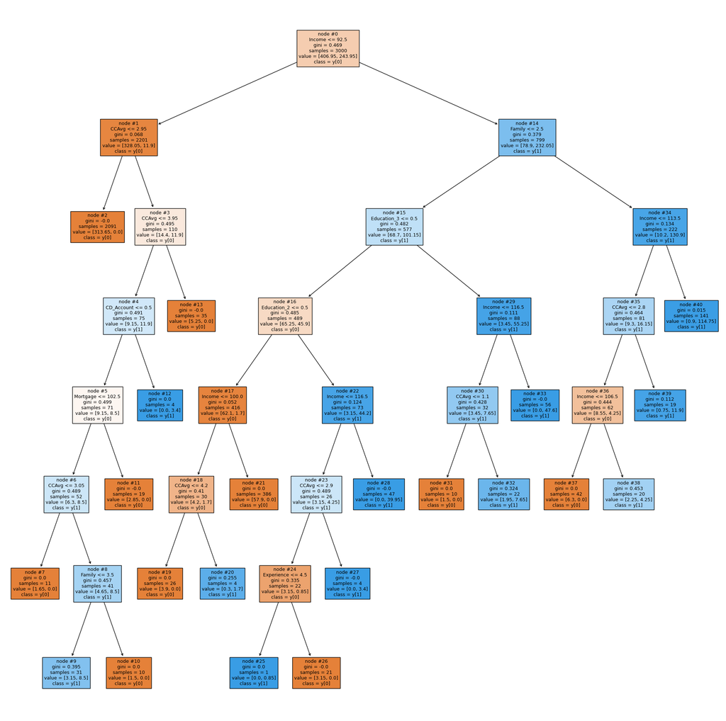

```python
plt.figure(figsize=(25, 25))

out = tree.plot_tree(
    best_model,
    feature_names=feature_names,
    filled=True,
    fontsize=9,
    node_ids=True,
    class_names=True,
)
for o in out:
    arrow = o.arrow_patch
    if arrow is not None:
        arrow.set_edgecolor("black")
        arrow.set_linewidth(1)
plt.show()
plt.show()
```

```python
# Text report showing the rules of a decision tree -

print(tree.export_text(best_model, feature_names=feature_names, show_weights=True))
```

```
|--- Income <= 92.50
|   |--- CCAvg <= 2.95
|   |   |--- weights: [313.65, 0.00] class: 0
|   |--- CCAvg >  2.95
|   |   |--- CCAvg <= 3.95
|   |   |   |--- CD_Account <= 0.50
|   |   |   |   |--- Mortgage <= 102.50
|   |   |   |   |   |--- CCAvg <= 3.05
|   |   |   |   |   |   |--- weights: [1.65, 0.00] class: 0
|   |   |   |   |   |--- CCAvg >  3.05
|   |   |   |   |   |   |--- Family <= 3.50
|   |   |   |   |   |   |   |--- weights: [3.15, 8.50] class: 1
|   |   |   |   |   |   |--- Family >  3.50
|   |   |   |   |   |   |   |--- weights: [1.50, 0.00] class: 0
|   |   |   |   |--- Mortgage >  102.50
|   |   |   |   |   |--- weights: [2.85, 0.00] class: 0
|   |   |   |--- CD_Account >  0.50
|   |   |   |   |--- weights: [0.00, 3.40] class: 1
|   |   |--- CCAvg >  3.95
|   |   |   |--- weights: [5.25, 0.00] class: 0
|--- Income >  92.50
|   |--- Family <= 2.50
|   |   |--- Education_3 <= 0.50
|   |   |   |--- Education_2 <= 0.50
|   |   |   |   |--- Income <= 100.00
|   |   |   |   |   |--- CCAvg <= 4.20
|   |   |   |   |   |   |--- weights: [3.90, 0.00] class: 0
|   |   |   |   |   |--- CCAvg >  4.20
|   |   |   |   |   |   |--- weights: [0.30, 1.70] class: 1
|   |   |   |   |--- Income >  100.00
|   |   |   |   |   |--- weights: [57.90, 0.00] class: 0
|   |   |   |--- Education_2 >  0.50
|   |   |   |   |--- Income <= 116.50
|   |   |   |   |   |--- CCAvg <= 2.90
|   |   |   |   |   |   |--- Experience <= 4.50
|   |   |   |   |   |   |   |--- weights: [0.00, 0.85] class: 1
|   |   |   |   |   |   |--- Experience >  4.50
|   |   |   |   |   |   |   |--- weights: [3.15, 0.00] class: 0
|   |   |   |   |   |--- CCAvg >  2.90
|   |   |   |   |   |   |--- weights: [0.00, 3.40] class: 1
|   |   |   |   |--- Income >  116.50
|   |   |   |   |   |--- weights: [0.00, 39.95] class: 1
|   |   |--- Education_3 >  0.50
|   |   |   |--- Income <= 116.50
|   |   |   |   |--- CCAvg <= 1.10
|   |   |   |   |   |--- weights: [1.50, 0.00] class: 0
|   |   |   |   |--- CCAvg >  1.10
|   |   |   |   |   |--- weights: [1.95, 7.65] class: 1
|   |   |   |--- Income >  116.50
|   |   |   |   |--- weights: [0.00, 47.60] class: 1
|   |--- Family >  2.50
|   |   |--- Income <= 113.50
|   |   |   |--- CCAvg <= 2.80
|   |   |   |   |--- Income <= 106.50
|   |   |   |   |   |--- weights: [6.30, 0.00] class: 0
|   |   |   |   |--- Income >  106.50
|   |   |   |   |   |--- weights: [2.25, 4.25] class: 1
|   |   |   |--- CCAvg >  2.80
|   |   |   |   |--- weights: [0.75, 11.90] class: 1
|   |   |--- Income >  113.50
|   |   |   |--- weights: [0.90, 114.75] class: 1
```

```python
# importance of features in the tree building ( The importance of a feature is computed as the
# (normalized) total reduction of the 'criterion' brought by that feature. It is also known as the Gini importance )

print(
    pd.DataFrame(
        best_model.feature_importances_, columns=["Imp"], index=X_train.columns
    ).sort_values(by="Imp", ascending=False)
)
```

```
                         Imp
Income              0.609852
Education_2         0.153775
CCAvg               0.083933
Education_3         0.073757
Family              0.063382
Mortgage            0.005424
CD_Account          0.005271
Experience          0.004605
ZIPCode_93          0.000000
ZIPCode_96          0.000000
ZIPCode_95          0.000000
ZIPCode_94          0.000000
Age                 0.000000
ZIPCode_92          0.000000
ZIPCode_91          0.000000
Online              0.000000
Securities_Account  0.000000
CreditCard          0.000000
```

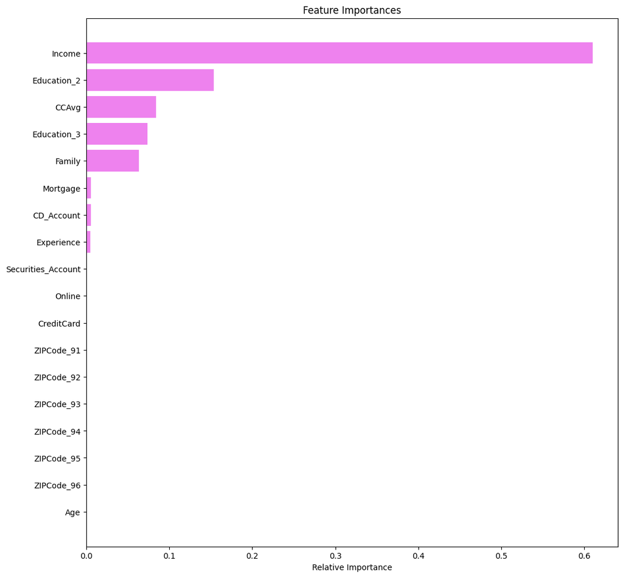

```python
importances = best_model.feature_importances_
indices = np.argsort(importances)

plt.figure(figsize=(12, 12))
plt.title("Feature Importances")
plt.barh(range(len(indices)), importances[indices], color="violet", align="center")
plt.yticks(range(len(indices)), [feature_names[i] for i in indices])
plt.xlabel("Relative Importance")
plt.show()
```

Income, Education_2, CCAvg, Education_3,Family are more important Variables in Predicting the Probable Customer accepting a loan as per Post Pruned Model

## Model Comparison and Final Model Selection

```python
# training performance comparison

models_train_comp_df = pd.concat(
    [
        decision_tree_perf_train.T,
        decision_tree_tune_perf_train.T,
        decision_tree_postpruned_perf_train.T,
    ],
    axis=1,
)
models_train_comp_df.columns = [
    "Decision Tree sklearn",
    "Decision Tree (Pre-Pruning)",
    "Decision Tree (Post-Pruning)",
]
print("Training performance comparison:")
models_train_comp_df
```

```
Training performance comparison:
```

|  | Decision Tree sklearn | Decision Tree (Pre-Pruning) | Decision Tree (Post-Pruning) |
| --- | --- | --- | --- |
| Accuracy | 1.0 | 0.963667 | 0.979333 |
| Recall | 1.0 | 0.993031 | 1.000000 |
| Precision | 1.0 | 0.727041 | 0.822350 |
| F1 | 1.0 | 0.839470 | 0.902516 |

```python
# test performance comparison

models_train_comp_df = pd.concat(
    [
        decision_tree_perf_test.T,
        decision_tree_tune_perf_test.T,
        decision_tree_postpruned_perf_test.T,
    ],
    axis=1,
)
models_train_comp_df.columns = [
    "Decision Tree sklearn",
    "Decision Tree (Pre-Pruning)",
    "Decision Tree (Post-Pruning)",
]
print("Test set performance comparison:")
models_train_comp_df
```

```
Test set performance comparison:
```

|  | Decision Tree sklearn | Decision Tree (Pre-Pruning) | Decision Tree (Post-Pruning) |
| --- | --- | --- | --- |
| Accuracy | 0.980000 | 0.955000 | 0.965500 |
| Recall | 0.880829 | 0.948187 | 0.932642 |
| Precision | 0.909091 | 0.695817 | 0.762712 |
| F1 | 0.894737 | 0.802632 | 0.839161 |

Feature Importance for Post Pruned Model

1. Income 60% - Higher the income, higher the chances of customer taking Personal Loan
2. Education_2(Graduation) 15% - Graduate Educated Customers have more chance of taking loan
3. CCAvg 8% - Customers who have high spending on Credit Card per month are more likely to take Loan
4. Education_3 7% - Advanced/Professional customers have more probability of taking loan
5. Family 6% - Customers with family size 3 or 4 are more likely to take loan

Analyzing the Performance of Models,

- Post Pruned Model give the highest recall with 100% on train data but 93% on test data with ccp_alpha = 0.002
- Pre Pruned Model has recall of 99% on train data and 94.8 % on test data.

Our Post Pruning and Pre Pruning Models are giving almost eqaul recall value for the test data. Test data was 40% of the sample data.

## We can choose Pre Pruned model which is simpler and gave nearly 95% Recall

## Actionable Insights and Business Recommendations

**What** **recommedations would you suggest to the bank?**

- Campaigns for Personal Loan should be targetted to Customers who have higher income.
- Target Customers with Graduate and Advanced/Professional Education who have high probability of accepting loan
- Customers who have Credit Cards and have higher monthly spending on the cards are more likely to take Loan.
- Target Customers with Family size of 3 or 4, who have more probability to take loan

# Questions:

### What is the distribution of mortgage attribute? Are there any noticeable patterns or outliers in the distribution?

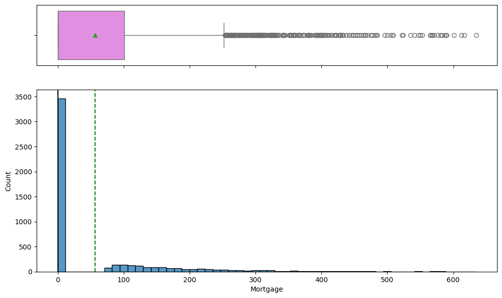

```python
histogram_boxplot(data, "Mortgage")
```

```python
data["Mortgage"].describe()
```

```
count    5000.000000
mean       56.498800
std       101.713802
min         0.000000
25%         0.000000
50%         0.000000
75%       101.000000
max       635.000000
Name: Mortgage, dtype: float64
```

Answer : Mortgage variable distribution is highly Right skewed with many outliers.

50% of customers doenst have mortgage. Some customers have maximum mortgage of 635.

### How many customers have credit cards?

```python
data["CreditCard"].value_counts()
```

```
CreditCard
0    3530
1    1470
Name: count, dtype: int64
```

Answer : From the data for Credit Card issued from other banks, there are 1470 customers with credit cards.

We wont be able to analyze number of Credit Card info from CCAvg data since its Customer spending in dollars.